# challenge2

## Challenge 2 - Visualization of Energy Consumptions

Challenger : Nobuto Yoshimura

```python
%matplotlib inline
```

```python
# -*- coding:utf-8 -*-
import numpy as np
import matplotlib.pyplot as plt
from matplotlib.colors import ListedColormap
import pandas as pd
from sklearn.cluster import KMeans
from datetime import datetime as dt
```

```python
#read data-set
df_total_watt = pd.read_csv('../total_watt.csv', parse_dates=['Timestamp'], names=['Timestamp','Energy'], header=0, index_col='Timestamp')
```

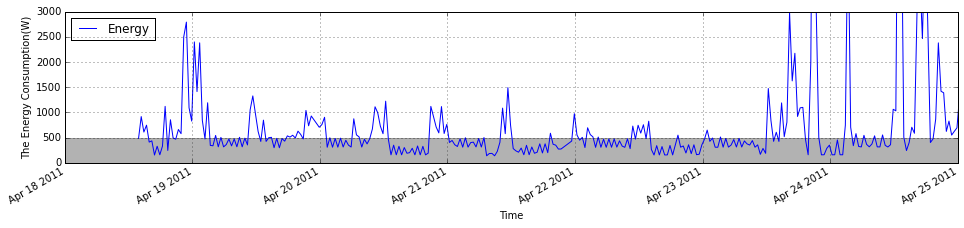

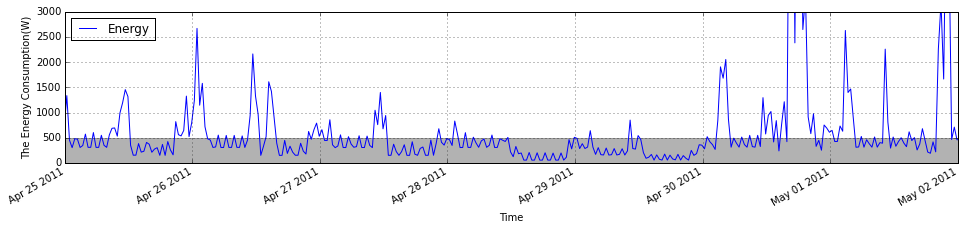

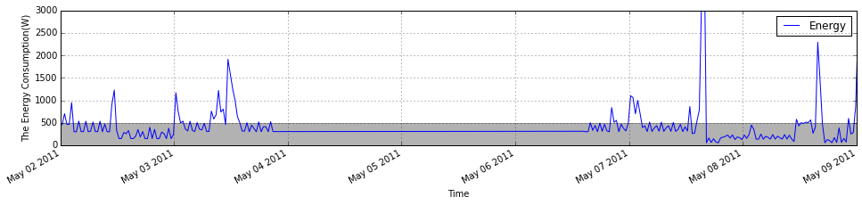

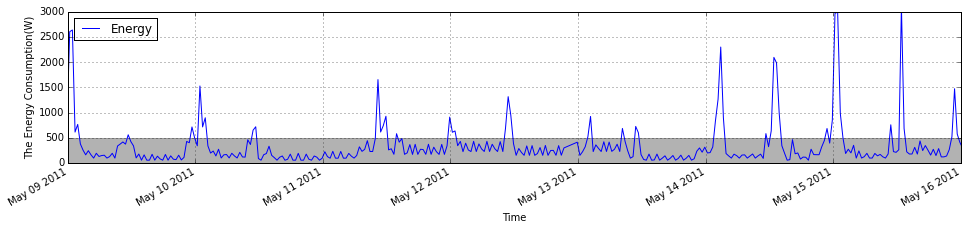

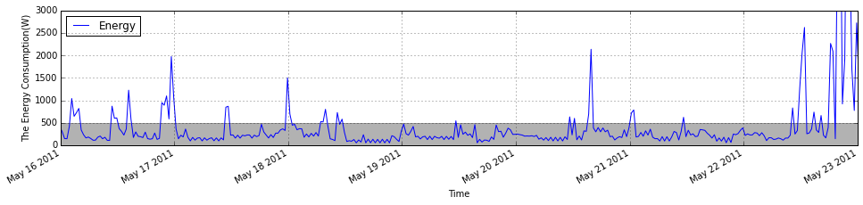

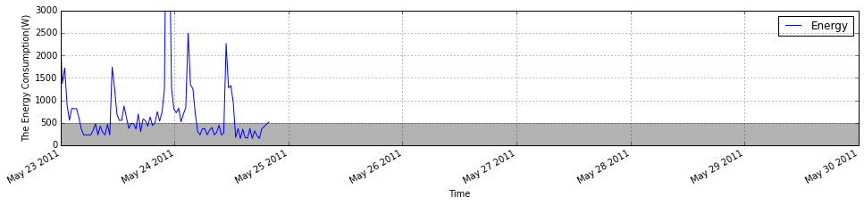

```python
#visualization of the data-set as values per 30mins

#plot energy consumption in weeks
df_total_watt.plot(figsize=(16,3))
plt.xlabel('Time')
plt.ylabel('The Energy Consumption(W)')
plt.axis(["2011-04-18 00:00:00", "2011-04-25 00:00:00" , 0, 3000])
plt.axhspan(0, 500, facecolor='k', alpha=0.3)

df_total_watt.plot(figsize=(16,3))
plt.xlabel('Time')
plt.ylabel('The Energy Consumption(W)')
plt.axis(["2011-04-25 00:00:00", "2011-05-02 00:00:00" , 0, 3000])
plt.axhspan(0, 500, facecolor='k', alpha=0.3)

df_total_watt.plot(figsize=(16,3))
plt.xlabel('Time')
plt.ylabel('The Energy Consumption(W)')
plt.axis(["2011-05-02 00:00:00", "2011-05-09 00:00:00" , 0, 3000])
plt.axhspan(0, 500, facecolor='k', alpha=0.3)

df_total_watt.plot(figsize=(16,3))
plt.xlabel('Time')
plt.ylabel('The Energy Consumption(W)')
plt.axis(["2011-05-09 00:00:00", "2011-05-16 00:00:00" , 0, 3000])
plt.axhspan(0, 500, facecolor='k', alpha=0.3)

df_total_watt.plot(figsize=(16,3))
plt.xlabel('Time')
plt.ylabel('The Energy Consumption(W)')
plt.axis(["2011-05-16 00:00:00", "2011-05-23 00:00:00" , 0, 3000])
plt.axhspan(0, 500, facecolor='k', alpha=0.3)

df_total_watt.plot(figsize=(16,3))
plt.xlabel('Time')
plt.ylabel('The Energy Consumption(W)')
plt.axis(["2011-05-23 00:00:00", "2011-05-30 00:00:00" , 0, 3000])
plt.axhspan(0, 500, facecolor='k', alpha=0.3)

plt.show()
```

The data-set is described in weeks to observe the variation. From these charts, it is confirmed as the qualitative features that

- In the weekdays, the energy consumption is increasing around noon and midnight.
- In some weekends, the amount of energy consumption becomes quite large.
- In some days, the data-set is lacking. These features are confirmed in later analyses.

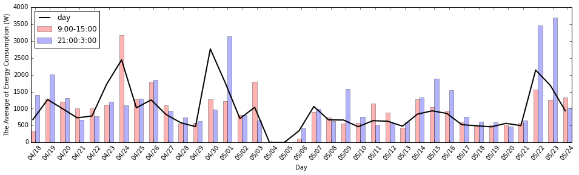

```python
#visualization of the data-set as values per day

#calculate energy consumption
date = pd.date_range('2011-04-18', '2011-05-24')
energy_part = np.zeros([6, len(date)])
for i, one_date in enumerate(date[:]):
    one_date = one_date.strftime('%Y-%m-%d')
    energy_part[0,i] = df_total_watt[one_date:one_date+' 03:00:00'].sum()
    energy_part[1,i] = df_total_watt[one_date+' 09:00:00':one_date+' 15:00:00'].sum()
    energy_part[2,i] = df_total_watt[one_date+' 21:00:00':one_date].sum()
    energy_part[3,i] = df_total_watt[one_date].sum()
    energy_part[4,i] = df_total_watt[one_date+' 03:00:00':one_date+' 09:00:00'].sum()
    energy_part[5,i] = df_total_watt[one_date+' 15:00:00':one_date+' 21:00:00'].sum()

#plot the average of energy consumption per day(average of daily, 9:00-15:00, and 21:00-3:00)
plt.figure(figsize=(16, 4))
ind = np.arange(len(date))
plt.bar(ind, (energy_part[1]/6), 0.3, color="r", alpha=0.3, align="center", label="9:00-15:00")
plt.bar(ind+0.3, (energy_part[0]+energy_part[2])/6, 0.3, color="b", alpha=0.3, align="center", label="21:00:3:00")
plt.plot(ind, (energy_part[3])/24, color='k', lw=2, label="day")
plt.xlabel('Day')
plt.ylabel('The Average of Energy Consumption (W)')
plt.xticks(ind+0.15, [dt.strftime(i, '%m/%d') for i in date], rotation=50)
plt.legend( loc='upper left')
plt.autoscale(enable=True, axis='x',tight=True)

plt.show()
```

In this chart, the average of energy consumption per day is described as black line. To confirm the first feature, the average around noon(9:00-15:00) and midnight(21:00-3:00) are visualized with bar chart, respectively. From this chart, it is confirmed that although the most average around noon or midnight is larger than the daily average, it is the other way around in some days(4/23(Sat), 4/30(Sat), 5/7(Sat), 5/20(Fri)) .

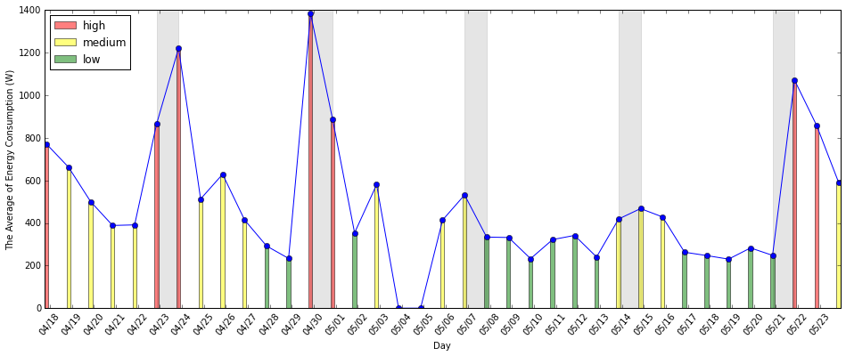

```python
#visualization of the data-set as clusters

#resample data-set from per 30mins to per day
df_daily = df_total_watt.resample('D', how='mean')

#clustering by kmeans
kmeans = KMeans(n_clusters=3)
kmeans.fit([[x] for x in df_daily.Energy.fillna(0).tolist()])
df_daily['label']=kmeans.labels_

#sorting label
label_sorted = sorted([df_daily.ix[df_daily.label == i].ix[0][0] for i in range(3)])
color_sorted = [0]*3
colors = ['green', 'yellow', 'red']
for i, label in enumerate(map(lambda x: df_daily.ix[df_daily.Energy == x].ix[0][1], label_sorted)):
    color_sorted[int(label)]=colors[i]

#plot the resampled average of energy consumption with bar chart
plt.figure(figsize=(16, 6))
plt.plot(df_daily.Energy.fillna(0), marker="o")
for row in range(df_daily.label.count()):
    color = color_sorted[int(df_daily.iloc[[ row]].label)]
    plt.bar(float(row)-0.1, df_daily.iloc[[ row]].Energy.fillna(0), 0.18, color=color, alpha=0.5)
plt.xticks(ind+0.15, [dt.strftime(i, '%m/%d') for i in date], rotation=50)
plt.xlabel('Day')
plt.ylabel('The Average of Energy Consumption (W)')
plt.autoscale(enable=True, axis='x',tight=True)
p = [0]*3
for i in range(3):
    p[i] = plt.Rectangle((0, 0), 1, 1, fc=colors[i], alpha=0.5)
plt.legend([p[2],p[1],p[0]], ["high","medium","low"],  loc='upper left')

#highlight the each weekends
plt.axvspan(5, 6, facecolor='k', alpha=0.1)
plt.axvspan(12, 13, facecolor='k', alpha=0.1)
plt.axvspan(19, 20, facecolor='k', alpha=0.1)
plt.axvspan(26, 27, facecolor='k', alpha=0.1)
plt.axvspan(33, 34, facecolor='k', alpha=0.1)

plt.show()
```

In this chart, the average of energy consumption per day is described with clustered information. Grey area highlights each weekends. From this chart, it is shown that the variation of energy consumption becomes large around each weekends.

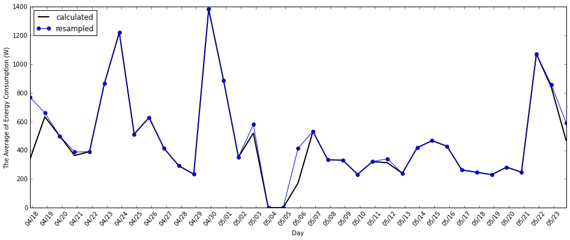

```python
#Appendix : visualization of the data-set as values per day to confirm the lack of data

#compare the calculated average of energy consumption with resampled one
plt.figure(figsize=(16, 6))
plt.plot(ind, (energy_part[3])/48, color='k', lw=2, label="calculated")
plt.plot(df_daily.Energy.fillna(0), marker="o", label="resampled")
plt.xticks(ind+0.15, [dt.strftime(i, '%m/%d') for i in date], rotation=50)
plt.autoscale(enable=True, axis='x',tight=True)
plt.xlabel('Day')
plt.ylabel('The Average of Energy Consumption (W)')
plt.legend( loc='upper left')

plt.show()
```

Finally, two types of chart is compared. Black line shows the calculated average of energy consumption per day and Blue line shows the resampled one. When the data-set is lacking, the calculated one becomes smaller than the resampled one. Therefore, the days with lack of data are visualized in this chart.